# R 기초

#### **Note**

- 본 문서는 R studio에서 markdown 포맷으로 만들었습니다. `ctrl+마우스 휠`로 자유롭게 폰트 조절이 가능합니다. (Default는 `ctrl + 숫자 0`) 본인의 시력에 맞추어 문서를 읽으시면 되겠습니다.
- 필요한 소프트웨어는 R base : [R project org](https://www.r-project.org), 는 R studio : [R studio](https://www.rstudio.com/)에서 다운로드 하십시오.
- 인터넷 익스플로러에서 보시는 것을 권장하며 (크롬도 가능하긴 하나 수식이 제대로 출력되지 않을 수 있음), 하단의 `차단된 콘텐츠 허용(A)` 버튼은 눌러주십시오. 별도의 Active X를 설치하는 것이 아니고, 스크립트 기반의 파일을 열기 때문에 경고가 나옵니다. 간혹 인터넷이 연결되어있지 않으면 수식이 깨져보일 수 있는데, 그 때는 크롬으로 열어서 보는 것을 권장합니다. 실습 수업에서 R의 모든 기능을 소개할 수가 없습니다. 부족한 부분은 [R을 이용한 데이터 처리 & 분석 실무](https://thebook.io/006723/) 를 참고하십시오.
- 프로그래밍은 반복연습이 필수입니다. 아무리 좋은 교재를 구매하고 비싼 교육을 받더라도 반복연습 하지 않으면 늘지 않습니다.

#### **1. 자료의 입력**

`c()` 함수를 이용하여 자료를 입력한다. 숫자는 그대로 입력하되 콤마`(,)`로 구분하며, 문자는 같은 방식을 사용하는데 값들을 따옴표`("")`로 감싸서 구분한다.

```r
x <- c(1,2,3,4)
y <- c("A","B","C","D")
```

위에서 값들이 저장되어있는 `x`, `y` 를 R에서는 객체(object)라고 부른다.

```r
x
```

```
## [1] 1 2 3 4
```

```r
print(x)
```

```
## [1] 1 2 3 4
```

```r
# 2번째 행까지만을 출력
head(x, n = 2)
```

```
## [1] 1 2
```

```r
# 객체 x의 길이
length(x)
```

```
## [1] 4
```

숫자형 자료가 연속적인 값일 경우에는 `seq()`함수를 사용하면 편하다.

```r
# 숫자 1부터 10까지 1간격으로 입력
seq(from = 1, to = 10, by = 1)
```

```
##  [1]  1  2  3  4  5  6  7  8  9 10
```

```r
# 숫자 1부터 10까지 1간격으로 입력
seq(from = 1, to = 10, by = 2)
```

```
## [1] 1 3 5 7 9
```

```r
# 숫자 1부터 10까지 등간격으로 10개 생성
seq(from = 1, to = 10, length.out = 10)
```

```
##  [1]  1  2  3  4  5  6  7  8  9 10
```

반복적인 자료에 대해서는 `rep()` 함수를 사용하면 편하다.

```r
# 1,2,3을 각각 3번씩 반복
rep(x = c(1,2,3), each = 3)
```

```
## [1] 1 1 1 2 2 2 3 3 3
```

```r
# 1,2,3을 3번 반복
rep(x = c(1,2,3), time = 3)
```

```
## [1] 1 2 3 1 2 3 1 2 3
```

```r
# 1,2,3, 1,2,3, 1,2,3을 3번 반복
rep(x = c(1,2,3), each = 3, time = 3)
```

```
##  [1] 1 1 1 2 2 2 3 3 3 1 1 1 2 2 2 3 3 3 1 1 1 2 2 2 3 3 3
```

```r
# 1,2,3을 각각 1, 2, 3번씩 반복
rep(x = c(1,2,3), time = c(1,2,3))
```

```
## [1] 1 2 2 3 3 3
```

```r
# A,B,C를 각각 1, 2, 3번씩 반복
rep(x = c("A","B","C"), time = c(1,2,3))
```

```
## [1] "A" "B" "B" "C" "C" "C"
```

`x`, `y`와 같이 하나의 자료만을 입력한 것들을 벡터(vector)라고 하며 같은 길이의 숫자형 벡터 2개 이상을 모아둔 것을 행렬(matrix)라고 한다. 같은 길이의 숫자형, 문자형 벡터 2개 이상을 모아둔 것을 데이터 프레임(data frame)라고 한다. 행렬은 숫자형 벡터들의 집합이므로 행렬 연산이 가능하며, 데이터 프레임의 경우에는 불가능하다.

```r
x <- c(1,2,3,4)
y <- c("A","B","C","D")
d <- cbind.data.frame(x,y)
d
```

```
##   x y
## 1 1 A
## 2 2 B
## 3 3 C
## 4 4 D
```

```r
class(d)
```

```
## [1] "data.frame"
```

```r
str(d)
```

```
## 'data.frame':    4 obs. of  2 variables:
##  $ x: num  1 2 3 4
##  $ y: Factor w/ 4 levels "A","B","C","D": 1 2 3 4
```

행렬은 $(X^{T}X)^{-1}$과 같은 전치행렬, 역행렬 등의 연산이 가능.

```r
x <- c(1,2,3,4)
y <- c(1,0,-1,2)
m <- cbind(x,y)
m
```

```
##      x  y
## [1,] 1  1
## [2,] 2  0
## [3,] 3 -1
## [4,] 4  2
```

```r
class(m)
```

```
## [1] "matrix"
```

```r
str(m)
```

```
##  num [1:4, 1:2] 1 2 3 4 1 0 -1 2
##  - attr(*, "dimnames")=List of 2
##   ..$ : NULL
##   ..$ : chr [1:2] "x" "y"
```

```r
t(m) %*% m
```

```
##    x y
## x 30 6
## y  6 6
```

```r
solve(t(m) %*% m)
```

```
##             x           y
## x  0.04166667 -0.04166667
## y -0.04166667  0.20833333
```

R에서는 리스트(list)라고 하는 특수한 형태의 자료 저장 방식이 있는데, 리스트는 여러가지 벡터, 행렬, 데이터 프레임의 결과를 저장할 수 있다.

```r
list(x=x,
     y=y,
     m=m,
     d=d)
```

```
## $x
## [1] 1 2 3 4
##
## $y
## [1]  1  0 -1  2
##
## $m
##      x  y
## [1,] 1  1
## [2,] 2  0
## [3,] 3 -1
## [4,] 4  2
##
## $d
##   x y
## 1 1 A
## 2 2 B
## 3 3 C
## 4 4 D
```

#### **2. 자료의 인덱싱(indexing)**

자료의 부분집합을 가져오거나 수정하는 작업을 인덱싱이라고 한다. 먼저 벡터에 대한 인덱싱은 아래와 같고,

```r
x <- seq(from=1, to = 10, by = 1)
x
```

```
##  [1]  1  2  3  4  5  6  7  8  9 10
```

```r
# 객체의 길이
length(x)
```

```
## [1] 10
```

```r
# 1번째 원소
x[1]
```

```
## [1] 1
```

```r
# 9번째 원소
x[9]
```

```
## [1] 9
```

```r
# 1번째 원소 제거
x[-1]
```

```
## [1]  2  3  4  5  6  7  8  9 10
```

```r
# 2,3번째 원소
x[c(2,3)]
```

```
## [1] 2 3
```

```r
# 3,9번째 원소 제거
x[-c(3,9)]
```

```
## [1]  1  2  4  5  6  7  8 10
```

```r
# 7 이상의 값
x[(x>=7)]
```

```
## [1]  7  8  9 10
```

```r
# 1번째 원소에 3을 대입하여 값을 수정
x[1] <- 3
x
```

```
##  [1]  3  2  3  4  5  6  7  8  9 10
```

```r
# 숫자 (3,4,5)에 해당하는 값이 있는지를 확인
x %in% c(3,4,5)
```

```
##  [1]  TRUE FALSE  TRUE  TRUE  TRUE FALSE FALSE FALSE FALSE FALSE
```

데이터 프레임에 대한 인덱싱을 설명하기 위해 R에 내장되어있는 `iris` 데이터셋을 로딩한다.

```r
# 1-5번째 행데이터까지만 출력
head(iris)
```

```
##   Sepal.Length Sepal.Width Petal.Length Petal.Width Species
## 1          5.1         3.5          1.4         0.2  setosa
## 2          4.9         3.0          1.4         0.2  setosa
## 3          4.7         3.2          1.3         0.2  setosa
## 4          4.6         3.1          1.5         0.2  setosa
## 5          5.0         3.6          1.4         0.2  setosa
## 6          5.4         3.9          1.7         0.4  setosa
```

```r
# 자료의 구조(structure)
str(iris)
```

```
## 'data.frame':    150 obs. of  5 variables:
##  $ Sepal.Length: num  5.1 4.9 4.7 4.6 5 5.4 4.6 5 4.4 4.9 ...
##  $ Sepal.Width : num  3.5 3 3.2 3.1 3.6 3.9 3.4 3.4 2.9 3.1 ...
##  $ Petal.Length: num  1.4 1.4 1.3 1.5 1.4 1.7 1.4 1.5 1.4 1.5 ...
##  $ Petal.Width : num  0.2 0.2 0.2 0.2 0.2 0.4 0.3 0.2 0.2 0.1 ...
##  $ Species     : Factor w/ 3 levels "setosa","versicolor",..: 1 1 1 1 1 1 1 1 1 1 ...
```

```r
# 자료의 차원(dimension)
dim(iris)
```

```
## [1] 150   5
```

```r
# 자료의 행 개수
nrow(iris)
```

```
## [1] 150
```

```r
# 자료의 열 개수
ncol(iris)
```

```
## [1] 5
```

데이터 프레임에 대한 인덱싱은 아래와 같다. 데이터 프레임의 `(i,j)`번째 원소에 대한 인덱싱은 `"데이터셋명"[i,j]`와 같은 방식으로 이루어진다. `j`번째 열에 대한 인덱싱은 `"데이터셋명"[,j]`와 같고, `i`번째 행에 대한 인덱싱은 `"데이터셋명"[i,]`와 같다. 데이터 프레임 내의 특정 변수에 대해 접근할 경우에는 `"데이터셋명"$"변수명"`과 같이 지정한다.

```r
# 1,3,5번째 행 자료
iris[c(1,3,5),]
```

```
##   Sepal.Length Sepal.Width Petal.Length Petal.Width Species
## 1          5.1         3.5          1.4         0.2  setosa
## 3          4.7         3.2          1.3         0.2  setosa
## 5          5.0         3.6          1.4         0.2  setosa
```

```r
# 1열-4열까지의 변수만을 가져옴
head(iris[,1:4])
```

```
##   Sepal.Length Sepal.Width Petal.Length Petal.Width
## 1          5.1         3.5          1.4         0.2
## 2          4.9         3.0          1.4         0.2
## 3          4.7         3.2          1.3         0.2
## 4          4.6         3.1          1.5         0.2
## 5          5.0         3.6          1.4         0.2
## 6          5.4         3.9          1.7         0.4
```

```r
# 1열-4열까지의 변수들의 평균
apply(iris[,1:4], MARGIN = 2, FUN = mean)
```

```
## Sepal.Length  Sepal.Width Petal.Length  Petal.Width
##     5.843333     3.057333     3.758000     1.199333
```

```r
# 1열-4열까지의 변수들의 열 기준 평균
colSums(iris[,1:4])
```

```
## Sepal.Length  Sepal.Width Petal.Length  Petal.Width
##        876.5        458.6        563.7        179.9
```

```r
# 1열-4열까지의 변수들의 행 기준 평균
rowSums(iris[,1:4])
```

```
##   [1] 10.2  9.5  9.4  9.4 10.2 11.4  9.7 10.1  8.9  9.6 10.8 10.0  9.3  8.5
##  [15] 11.2 12.0 11.0 10.3 11.5 10.7 10.7 10.7  9.4 10.6 10.3  9.8 10.4 10.4
##  [29] 10.2  9.7  9.7 10.7 10.9 11.3  9.7  9.6 10.5 10.0  8.9 10.2 10.1  8.4
##  [43]  9.1 10.7 11.2  9.5 10.7  9.4 10.7  9.9 16.3 15.6 16.4 13.1 15.4 14.3
##  [57] 15.9 11.6 15.4 13.2 11.5 14.6 13.2 15.1 13.4 15.6 14.6 13.6 14.4 13.1
##  [71] 15.7 14.2 15.2 14.8 14.9 15.4 15.8 16.4 14.9 12.8 12.8 12.6 13.6 15.4
##  [85] 14.4 15.5 16.0 14.3 14.0 13.3 13.7 15.1 13.6 11.6 13.8 14.1 14.1 14.7
##  [99] 11.7 13.9 18.1 15.5 18.1 16.6 17.5 19.3 13.6 18.3 16.8 19.4 16.8 16.3
## [113] 17.4 15.2 16.1 17.2 16.8 20.4 19.5 14.7 18.1 15.3 19.2 15.7 17.8 18.2
## [127] 15.6 15.8 16.9 17.6 18.2 20.1 17.0 15.7 15.7 19.1 17.7 16.8 15.6 17.5
## [141] 17.8 17.4 15.5 18.2 18.2 17.2 15.7 16.7 17.3 15.8
```

```r
# Sepal.Length 변수에 대한 평균
mean(iris$Sepal.Length)
```

```
## [1] 5.843333
```

`subset()` 함수는 조건을 만족하는 자료의 부분집합을 가져오는 함수인데, 사용 예는 아래와 같다. R의 인덱싱 기능은 생각보다 많은 것을 할 수 있게 해주며 따라서 별도의 SQL 문법을 사용하지 않는 경우가 많다.

```r
# Species 변수가 virginica인 행 자료
head(subset(iris, Species=="virginica"))
```

```
##     Sepal.Length Sepal.Width Petal.Length Petal.Width   Species
## 101          6.3         3.3          6.0         2.5 virginica
## 102          5.8         2.7          5.1         1.9 virginica
## 103          7.1         3.0          5.9         2.1 virginica
## 104          6.3         2.9          5.6         1.8 virginica
## 105          6.5         3.0          5.8         2.2 virginica
## 106          7.6         3.0          6.6         2.1 virginica
```

```r
# Species 변수의 첫 글자가 v인 행 자료
head(subset(iris, substr(x=Species, start=1, stop=1)=="v"))
```

```
##    Sepal.Length Sepal.Width Petal.Length Petal.Width    Species
## 51          7.0         3.2          4.7         1.4 versicolor
## 52          6.4         3.2          4.5         1.5 versicolor
## 53          6.9         3.1          4.9         1.5 versicolor
## 54          5.5         2.3          4.0         1.3 versicolor
## 55          6.5         2.8          4.6         1.5 versicolor
## 56          5.7         2.8          4.5         1.3 versicolor
```

```r
# (Sepal.Length > 7.5) and (Sepal.Width > 3 인 행 자료
iris[ (iris$Sepal.Length > 7.5) & (iris$Sepal.Width > 3), ]
```

```
##     Sepal.Length Sepal.Width Petal.Length Petal.Width   Species
## 118          7.7         3.8          6.7         2.2 virginica
## 132          7.9         3.8          6.4         2.0 virginica
```

```r
# (Species = setosa) and (Sepal.Width > 4 인 행 자료
iris[ (iris$Species=="setosa") & (iris$Sepal.Width > 4), ]
```

```
##    Sepal.Length Sepal.Width Petal.Length Petal.Width Species
## 16          5.7         4.4          1.5         0.4  setosa
## 33          5.2         4.1          1.5         0.1  setosa
## 34          5.5         4.2          1.4         0.2  setosa
```

#### **3. 자료의 처리**

자료에서 특정변수를 기준으로 분리하고 싶을 때가 있다. `split()` 함수는 이것을 가능하게 해주는 함수이다. `split()` 함수로 분리된 자료들은 리스트 형태의 오브젝트로 저장된다. 따라서 head() 함수로 분리된 자료들의 1-5번째 행까지를 보고 싶을 경우, `lapply()` 함수를 사용해야만 한다. `lapply()` 함수는 리스트 객체에 매우 유용한 함수로써 R에서 반드시 익혀두어야 할 함수 중 하나이다. 첫번째 input에 리스트 오브젝트를, 두번째 input 에 각 리스트 원소들에 적용할 함수를 설정한다. 함수는 R 내장함수는 모두 가능하며 사용자 정의의 함수 또한 가능하다.

```r
head(iris)
```

```
##   Sepal.Length Sepal.Width Petal.Length Petal.Width Species
## 1          5.1         3.5          1.4         0.2  setosa
## 2          4.9         3.0          1.4         0.2  setosa
## 3          4.7         3.2          1.3         0.2  setosa
## 4          4.6         3.1          1.5         0.2  setosa
## 5          5.0         3.6          1.4         0.2  setosa
## 6          5.4         3.9          1.7         0.4  setosa
```

```r
iris.split <- split(x=iris, f=iris$Species)

head(iris.split$setosa)
```

```
##   Sepal.Length Sepal.Width Petal.Length Petal.Width Species
## 1          5.1         3.5          1.4         0.2  setosa
## 2          4.9         3.0          1.4         0.2  setosa
## 3          4.7         3.2          1.3         0.2  setosa
## 4          4.6         3.1          1.5         0.2  setosa
## 5          5.0         3.6          1.4         0.2  setosa
## 6          5.4         3.9          1.7         0.4  setosa
```

```r
head(iris.split$versicolor)
```

```
##    Sepal.Length Sepal.Width Petal.Length Petal.Width    Species
## 51          7.0         3.2          4.7         1.4 versicolor
## 52          6.4         3.2          4.5         1.5 versicolor
## 53          6.9         3.1          4.9         1.5 versicolor
## 54          5.5         2.3          4.0         1.3 versicolor
## 55          6.5         2.8          4.6         1.5 versicolor
## 56          5.7         2.8          4.5         1.3 versicolor
```

```r
head(iris.split$virginica)
```

```
##     Sepal.Length Sepal.Width Petal.Length Petal.Width   Species
## 101          6.3         3.3          6.0         2.5 virginica
## 102          5.8         2.7          5.1         1.9 virginica
## 103          7.1         3.0          5.9         2.1 virginica
## 104          6.3         2.9          5.6         1.8 virginica
## 105          6.5         3.0          5.8         2.2 virginica
## 106          7.6         3.0          6.6         2.1 virginica
```

```r
# 리스트 원소마다 head()
lapply(iris.split, function(x) head(x))
```

```
## $setosa
##   Sepal.Length Sepal.Width Petal.Length Petal.Width Species
## 1          5.1         3.5          1.4         0.2  setosa
## 2          4.9         3.0          1.4         0.2  setosa
## 3          4.7         3.2          1.3         0.2  setosa
## 4          4.6         3.1          1.5         0.2  setosa
## 5          5.0         3.6          1.4         0.2  setosa
## 6          5.4         3.9          1.7         0.4  setosa
##
## $versicolor
##    Sepal.Length Sepal.Width Petal.Length Petal.Width    Species
## 51          7.0         3.2          4.7         1.4 versicolor
## 52          6.4         3.2          4.5         1.5 versicolor
## 53          6.9         3.1          4.9         1.5 versicolor
## 54          5.5         2.3          4.0         1.3 versicolor
## 55          6.5         2.8          4.6         1.5 versicolor
## 56          5.7         2.8          4.5         1.3 versicolor
##
## $virginica
##     Sepal.Length Sepal.Width Petal.Length Petal.Width   Species
## 101          6.3         3.3          6.0         2.5 virginica
## 102          5.8         2.7          5.1         1.9 virginica
## 103          7.1         3.0          5.9         2.1 virginica
## 104          6.3         2.9          5.6         1.8 virginica
## 105          6.5         3.0          5.8         2.2 virginica
## 106          7.6         3.0          6.6         2.1 virginica
```

```r
# Sepal.Length 마다의 평균
lapply(iris.split, function(x) mean(x$Sepal.Length))
```

```
## $setosa
## [1] 5.006
##
## $versicolor
## [1] 5.936
##
## $virginica
## [1] 6.588
```

두 데이터 프레임 간에 병합(merge)를 해야만 하는 상황이 있을 수 있다. R에서 `merge()`라는 함수를 이용한다. 우선 R의 `merge`는 병합 방식에 따라 다음의 여러 가지 상황이 존재한다.

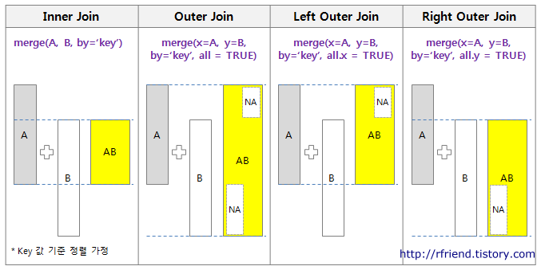

`merge()` 함수에는 병합에 사용될 두 개의 데이터셋을 지정하는 부분과 어떤 변수를 key 변수로 하여 병합할 것인지를 지정해주어야 한다. 그리고 병합 방식에 따라 `all`, `all.x`, `all.y`와 같은 옵션을 활성화 한다.

```r
(x <- data.frame(name=c("a", "b", "c"), math=c(1, 2, 3)))
```

```
##   name math
## 1    a    1
## 2    b    2
## 3    c    3
```

```r
(y <- data.frame(name=c("a", "b", "c", "d"), englise=c(4, 5, 6, 7)))
```

```
##   name englise
## 1    a       4
## 2    b       5
## 3    c       6
## 4    d       7
```

```r
# Inner join
merge(x=x, y=y, by="name")
```

```
##   name math englise
## 1    a    1       4
## 2    b    2       5
## 3    c    3       6
```

```r
# Outer join
merge(x=x, y=y, by="name", all=TRUE)
```

```
##   name math englise
## 1    a    1       4
## 2    b    2       5
## 3    c    3       6
## 4    d   NA       7
```

```r
# Left join
merge(x=x, y=y, by="name", all.x=TRUE)
```

```
##   name math englise
## 1    a    1       4
## 2    b    2       5
## 3    c    3       6
```

```r
# Right join
merge(x=x, y=y, by="name", all.y=TRUE)
```

```
##   name math englise
## 1    a    1       4
## 2    b    2       5
## 3    c    3       6
## 4    d   NA       7
```

정렬 함수로는 `sort()`와 `order()`가 있다. `sort()`는 하나의 벡터 변수에 대한 정렬만을 수행하며, `order()`는 데이터 프레임 내에서 특정 변수를 기준으로 정렬을 가능하게 해준다.

```r
(x <- c(1,4,8,2,3))
```

```
## [1] 1 4 8 2 3
```

```r
sort(x, decreasing=FALSE)
```

```
## [1] 1 2 3 4 8
```

```r
sort(x, decreasing=TRUE)
```

```
## [1] 8 4 3 2 1
```

```r
head(iris)
```

```
##   Sepal.Length Sepal.Width Petal.Length Petal.Width Species
## 1          5.1         3.5          1.4         0.2  setosa
## 2          4.9         3.0          1.4         0.2  setosa
## 3          4.7         3.2          1.3         0.2  setosa
## 4          4.6         3.1          1.5         0.2  setosa
## 5          5.0         3.6          1.4         0.2  setosa
## 6          5.4         3.9          1.7         0.4  setosa
```

```r
# Sepal.Length 변수를 오름차순으로 정렬
head(iris[order(iris$Sepal.Length, decreasing = F),])
```

```
##    Sepal.Length Sepal.Width Petal.Length Petal.Width Species
## 14          4.3         3.0          1.1         0.1  setosa
## 9           4.4         2.9          1.4         0.2  setosa
## 39          4.4         3.0          1.3         0.2  setosa
## 43          4.4         3.2          1.3         0.2  setosa
## 42          4.5         2.3          1.3         0.3  setosa
## 4           4.6         3.1          1.5         0.2  setosa
```

```r
# 1. 먼저 Sepal.Length 변수를 오름차순으로 정렬
# 2. 이어서 Petal.Length 변수를 오름차순으로 정렬하되 1의 정렬 순서에 맞춤
head(iris[order(iris$Sepal.Length, iris$Petal.Length, decreasing = F),])
```

```
##    Sepal.Length Sepal.Width Petal.Length Petal.Width Species
## 14          4.3         3.0          1.1         0.1  setosa
## 39          4.4         3.0          1.3         0.2  setosa
## 43          4.4         3.2          1.3         0.2  setosa
## 9           4.4         2.9          1.4         0.2  setosa
## 42          4.5         2.3          1.3         0.3  setosa
## 23          4.6         3.6          1.0         0.2  setosa
```

#### **4. 플롯(Plot)**

플롯의 종류는 너무 많아서 모든 경우를 다루기가 어려우므로, 여기서는 회귀모형을 세우기 전에 주로 보게 되는 산점도(scatter plot)의 경우만을 설명하고자 한다.

R에서 산점도는 `plot()` 함수를 쓰면 되는데, 문법은 2가지이다. `x`축과 `y`축의 값을 직접 지정해주는 방법과 `formula`를 사용하는 방법이다. 데이터 프레임으로 되어있는 오브젝트에서 산점도를 그릴 경우를 가정하자. 첫번째 방법은 데이터 프레임 내부의 변수들을 지정해주기 위해 `"데이터셋명"$"변수명"` 과 같은 방식으로 산점도를 그린다. 여기서 `xlab`, `ylab`은 그림 내의 `x`축 `y`축의 레이블을 지정하는 부분이다. 보통 산점도는 깔끔하게 그려서 다른 사람에게 보여주는 경우가 많기 때문에 이러한 세부적인 옵션은 반드시 공부해서 익혀둘 필요가 있다.

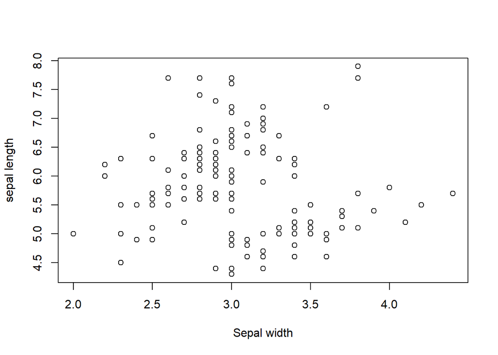

```r
# y축은 Sepal.Length, x축은 Sepal.Width
plot(
   x = iris$Sepal.Width,
   y = iris$Sepal.Length,
   xlab = "Sepal width",
   ylab = "sepal length"
)
```

후자의 경우, `y축의 변수 ~ x축의 변수`와 같은 `formula`를 지정한 다음, 옵션에서 `data = "데이터명"`을 지정함으로써 산점도를 그린다.

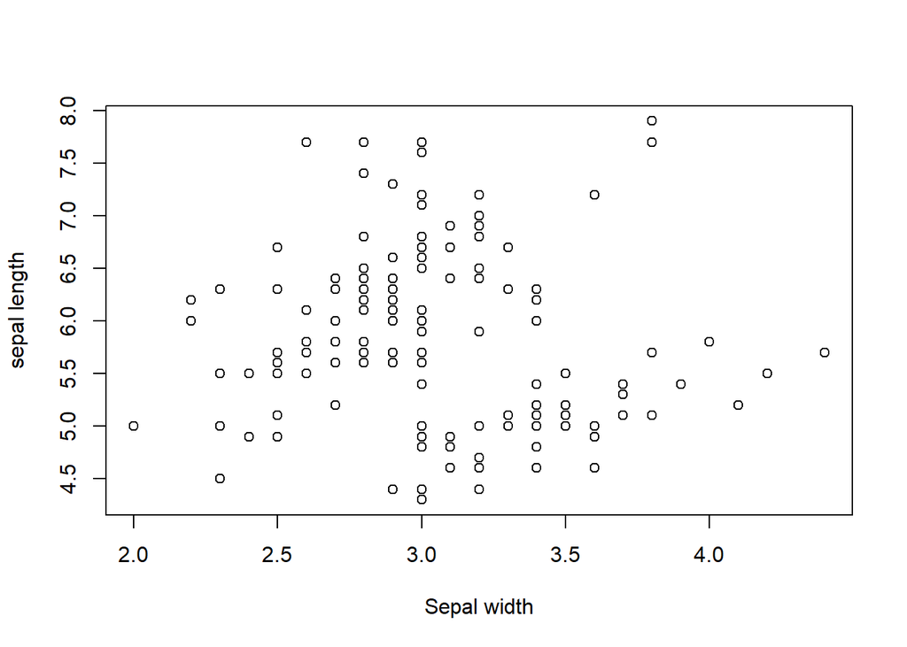

```r
plot(Sepal.Length ~ Sepal.Width,
     data=iris,
     xlab = "Sepal width",
     ylab = "sepal length")
```

산점도를 그리는 이유는 `y`축의 반응변수와 `x`축의 설명변수 간의 선형관계를 보기 위함이다. 따라서 산점도를 그린 다음에, 그림 위에 두 변수 간의 관계를 개략적으로 살펴보기 위해 평활선(smoothed line)을 그려본다. R 기본함수로 2가지가 제공된다. `supsmu()`와 `lowess()` 함수로써 `lines()` 함수를 이용하여 산점도 위에 덧씌어 그린다. `lty`는 선의 종류를 지정하는 옵션이며, `col`은 선의 색상을 지정하는 옵션이다. `legend()` 함수는 범례(legend)를 작성하는 함수이다. 이러한 옵션들에 대한 자세한 사항들은 구글링이나 교재를 참고하고 많이 연습하도록 하자. 연습하는 만큼 익숙해진다.

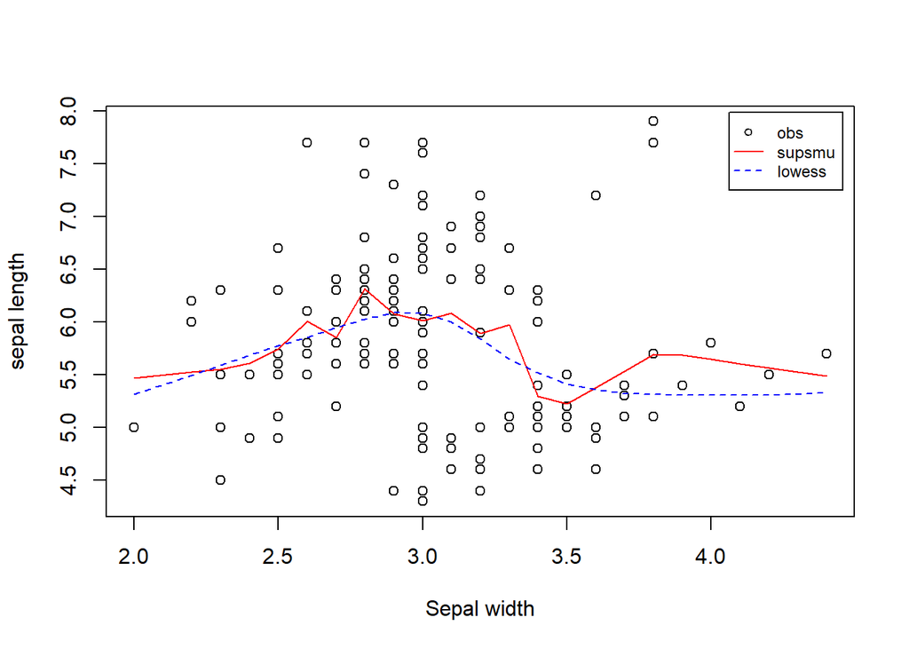

```r
# scatter plot
plot(
   x = iris$Sepal.Width,
   y = iris$Sepal.Length,
   xlab = "Sepal width",
   ylab = "sepal length"
   )

# adding supsmu line
lines(
   supsmu(
      x = iris$Sepal.Width,
      y = iris$Sepal.Lengt
   ),
   lty = 1,
   col = "red"
)

# adding lowess line
lines(
   lowess(
      x = iris$Sepal.Width,
      y = iris$Sepal.Lengt
   ),
   lty = 2,
   col = "blue"
)

# adding legend
legend(
   "topright",
   legend = c("obs", "supsmu", "lowess"),
   inset = c(0.015, 0.015),
   col = c("black", "red", "blue"),
   pch = c(1,NA,NA),
   lty = c(NA,1,2),
   cex = 0.75
)
```